# Elsevier 2022 SDG mapping

"unbanked"

)

OR TITLE-ABS

(

"affordable credit"

)

OR AUTHKEY

(

"affordable credit"

)

OR

(

TITLE-ABS

(

"small business"

)

AND TITLE-ABS

(

"credit"

)

)

OR

(

AUTHKEY

(

"small business"

)

AND AUTHKEY

(

"credit"

)

)

OR TITLE-ABS

(

"credit cooperatives"

)

OR AUTHKEY

(

"credit cooperatives"

)

OR

(

TITLE-ABS

(

"microenterprise"

)

AND TITLE-ABS

(

"credit"

)

)

OR

(

AUTHKEY

(

"microenterprise"

)

AND AUTHKEY

(

"credit"

)

)

OR TITLE-ABS

(

"microinsurance"

)

OR AUTHKEY

(

"microinsurance"

)

OR

(

TITLE-ABS

(

"microenterprise"

)

AND TITLE-ABS

(

"loans"

)

)

OR

(

AUTHKEY

(

"microenterprise"

)

AND AUTHKEY

(

"loans"

)

)

OR

(

TITLE-ABS

(

"empowerment"

)

AND TITLE-ABS

(

"credit"

)

)

OR

(

AUTHKEY

(

"empowerment"

)

AND AUTHKEY

(

"credit"

)

)

OR

(

TITLE-ABS

(

"micro-finance"

)

OR TITLE-ABS

(

"microfinance"

)

)

OR

(

AUTHKEY

(

"micro-finance"

)

OR AUTHKEY

(

"microfinance"

)

)

OR TITLE-ABS

(

"microfinancing"

)

OR AUTHKEY

(

"microfinancing"

)

OR

(

TITLE-ABS

(

"microenterprise"

)

AND TITLE-ABS

(

"loan"

)

)

OR

(

AUTHKEY

(

"microenterprise"

)

AND AUTHKEY

(

"loan"

)

)

OR TITLE-ABS

(

"cooperative banks"

)

OR AUTHKEY

(

"cooperative banks"

)

OR TITLE-ABS

(

"micro insurance"

)

OR AUTHKEY

(

"micro insurance"

)

OR TITLE-ABS

(

"group lending"

)

OR AUTHKEY

(

"group lending"

)

)

)

OR

(

(

(

TITLE-ABS

(

"scale and scope"

)

AND TITLE-ABS

(

"industr*"

)

)

OR

(

AUTHKEY

(

"scale and scope"

)

AND AUTHKEY

(

"industr*"

)

)

OR

(

TITLE-ABS

(

"economic growth"

)

AND TITLE-ABS

(

"labour* market*"

)

)

OR

(

AUTHKEY

(

"economic growth"

)

AND AUTHKEY

(

"labour* market*"

)

)

OR

(

TITLE-ABS

(

"economic growth"

)

AND TITLE-ABS

(

"technological"

)

)

OR

(

AUTHKEY

(

"economic growth"

)

AND AUTHKEY

(

"technological"

)

)

OR

(

TITLE-ABS

(

"GDP growth"

)

AND TITLE-ABS

(

"co integration"

)

)

OR

(

AUTHKEY

(

"GDP growth"

)

AND AUTHKEY

(

"co integration"

)

)

OR

(

TITLE-ABS

(

"economic growth"

)

AND TITLE-ABS

(

"sustained"

)

)

OR

(

AUTHKEY

(

"economic growth"

)

AND AUTHKEY

(

"sustained"

)

)

OR

(

TITLE-ABS

(

"economic growth"

)

AND TITLE-ABS

(

"labour mobility"

)

)

OR

(

AUTHKEY

(

"economic growth"

)

AND AUTHKEY

(

"labour mobility"

)

)

OR TITLE-ABS

(

"tfp growth"

)

OR AUTHKEY

(

"tfp growth"

)

OR

(

TITLE-ABS

(

"economic growth"

)

AND TITLE-ABS

(

"co integration"

)

)

OR

(

AUTHKEY

(

"economic growth"

)

AND AUTHKEY

(

"co integration"

)

)

OR

(

TITLE-ABS

(

"economic growth"

)

AND TITLE-ABS

(

"labour productivity"

)

)

OR

(

AUTHKEY

(

"economic growth"

)

AND AUTHKEY

(

"labour productivity"

)

)

OR

(

TITLE-ABS

(

"GDP growth"

)

AND TITLE-ABS

(

"physical capital"

)

)

OR

(

AUTHKEY

(

"GDP growth"

)

AND AUTHKEY

(

"physical capital"

)

)

OR

(

TITLE-ABS

(

"economic growth"

)

AND TITLE-ABS

(

"female labour"

)

)

OR

(

AUTHKEY

(

"economic growth"

)

AND AUTHKEY

(

"female labour"

)

)

OR

(

(

TITLE-ABS("long-term") AND TITLE-ABS("growth rate") AND TITLE-ABS("economics")

)

OR

(

TITLE-ABS("longterm") AND TITLE-ABS("growth rate") AND TITLE-ABS("economics")

)

)

OR

(

(

AUTHKEY("long-term") AND AUTHKEY("growth rate") AND AUTHKEY("economics")

)

OR

(

AUTHKEY("longterm") AND AUTHKEY("growth rate") AND AUTHKEY("economics")

)

)

OR

(

TITLE-ABS

(

"GDP growth"

)

AND TITLE-ABS

(

"value added"

)

)

OR

(

AUTHKEY

(

"GDP growth"

)

AND AUTHKEY

(

"value added"

)

)

OR TITLE-ABS

(

"economic growth pattern"

)

OR AUTHKEY

(

"economic growth pattern"

)

OR TITLE-ABS

(

"total factor productivity"

)

OR AUTHKEY

(

"total factor productivity"

)

OR TITLE-ABS

(

"regional growth"

)

OR AUTHKEY

(

"regional growth"

)

OR

(

TITLE-ABS

(

"economic growth"

)

AND TITLE-ABS

(

"cointegration"

)

)

OR

(

AUTHKEY

(

"economic growth"

)

AND AUTHKEY

(

"cointegration"

)

)

OR

(

TITLE-ABS

(

"economies of scale"

)

AND TITLE-ABS

(

"industr*"

)

)

OR

(

AUTHKEY

(

"economies of scale"

)

AND AUTHKEY

(

"industr*"

)

)

OR

(

(

TITLE-ABS("long-term") AND TITLE-ABS("economic growth")

)

OR

(

TITLE-ABS("longterm") AND TITLE-ABS("economic growth")

)

)

OR

(

(

AUTHKEY("long-term") AND AUTHKEY("economic growth")

)

OR

(

AUTHKEY("longterm") AND AUTHKEY("economic growth")

)

)

OR

(

TITLE-ABS

(

"economic growth"

)

AND TITLE-ABS

(

"capital accumulation"

)

)

OR

(

AUTHKEY

(

"economic growth"

)

AND AUTHKEY

(

"capital accumulation"

)

)

OR TITLE-ABS

(

"rapid economic growth"

)

OR AUTHKEY

(

"rapid economic growth"

)

OR TITLE-ABS

(

"sustained per capita growth"

)

OR AUTHKEY

(

"sustained per capita growth"

)

OR

(

TITLE-ABS

(

"economic growth"

)

AND TITLE-ABS

(

"labour* right*"

)

)

OR

(

AUTHKEY

(

"economic growth"

)

AND AUTHKEY

(

"labour* right*"

)

)

OR

(

TITLE-ABS

(

"GDP growth"

)

AND TITLE-ABS

(

"labour productivity"

)

)

OR

(

AUTHKEY

(

"GDP growth"

)

AND AUTHKEY

(

"labour productivity"

)

)

OR

(

TITLE-ABS

(

"labor productivity"

)

AND TITLE-ABS

(

"economic*"

)

)

OR

(

AUTHKEY

(

"labor productivity"

)

AND AUTHKEY

(

"economic*"

)

)

OR

(

TITLE-ABS

(

"GDP growth"

)

AND TITLE-ABS

(

"labour supply"

)

)

OR

(

AUTHKEY

(

"GDP growth"

)

AND AUTHKEY

(

"labour supply"

)

)

OR TITLE-ABS

(

"fast economic growth"

)

OR AUTHKEY

(

"fast economic growth"

)

OR

(

TITLE-ABS

(

"economic growth"

)

AND TITLE-ABS

(

"human capital"

)

)

OR

(

AUTHKEY

(

"economic growth"

)

AND AUTHKEY

(

"human capital"

)

)

OR

(

TITLE-ABS

(

"GDP growth"

)

AND TITLE-ABS

(

"long run"

)

)

OR

(

AUTHKEY

(

"GDP growth"

)

AND AUTHKEY

(

"long run"

)

)

OR

(

TITLE-ABS

(

"productive efficiency"

)

AND TITLE-ABS

(

"economic*"

)

)

OR

(

AUTHKEY

(

"productive efficiency"

)

AND AUTHKEY

(

"economic*"

)

)

OR

(

TITLE-ABS

(

"scope economies"

)

AND TITLE-ABS

(

"industr*"

)

)

OR

(

AUTHKEY

(

"scope economies"

)

AND AUTHKEY

(

"industr*"

)

)

OR

(

TITLE-ABS

(

"economic growth"

)

AND TITLE-ABS

(

"labour* migration*"

)

)

OR

(

AUTHKEY

(

"economic growth"

)

AND AUTHKEY

(

"labour* migration*"

)

)

OR TITLE-ABS

(

"endogenous growth model"

)

OR AUTHKEY

(

"endogenous growth model"

)

OR TITLE-ABS

(

"technology shock"

)

OR AUTHKEY

(

"technology shock"

)

OR

(

TITLE-ABS

(

"GDP growth"

)

AND TITLE-ABS

(

"labour force"

)

)

OR

(

AUTHKEY

(

"GDP growth"

)

AND AUTHKEY

(

"labour force"

)

)

OR

(

TITLE-ABS

(

"GDP growth"

)

AND TITLE-ABS

(

"human capital"

)

)

OR

(

AUTHKEY

(

"GDP growth"

)

AND AUTHKEY

(

"human capital"

)

)

OR

(

TITLE-ABS

(

"economic growth"

)

AND TITLE-ABS

(

"error correction"

)

)

OR

(

AUTHKEY

(

"economic growth"

)

AND AUTHKEY

(

"error correction"

)

)

OR TITLE-ABS

(

"firm productivity"

)

OR AUTHKEY

(

"firm productivity"

)

OR TITLE-ABS

(

"industrial productivity"

)

OR AUTHKEY

(

"industrial productivity"

)

OR TITLE-ABS

(

"drivers of economic growth"

)

OR AUTHKEY

(

"drivers of economic growth"

)

OR

(

TITLE-ABS

(

"productivity"

)

AND TITLE-ABS

(

"GDP"

)

)

OR

(

AUTHKEY

(

"productivity"

)

AND AUTHKEY

(

"GDP"

)

)

OR

(

TITLE-ABS

(

"GDP growth"

)

AND TITLE-ABS

(

"female labour"

)

)

OR

(

AUTHKEY

(

"GDP growth"

)

AND AUTHKEY

(

"female labour"

)

)

OR

(

TITLE-ABS

(

"GDP growth"

)

AND TITLE-ABS

(

"cointegration"

)

)

OR

(

AUTHKEY

(

"GDP growth"

)

AND AUTHKEY

(

"cointegration"

)

)

OR

(

TITLE-ABS

(

"economic growth"

)

AND TITLE-ABS

(

"physical capital"

)

)

OR

(

AUTHKEY

(

"economic growth"

)

AND AUTHKEY

(

"physical capital"

)

)

OR

(

TITLE-ABS

(

"economic growth"

)

AND TITLE-ABS

(

"value added"

)

)

OR

(

AUTHKEY

(

"economic growth"

)

AND AUTHKEY

(

"value added"

)

)

OR

(

TITLE-ABS

(

"economic growth"

)

AND TITLE-ABS

(

"neoclassical"

)

)

OR

(

AUTHKEY

(

"economic growth"

)

AND AUTHKEY

(

"neoclassical"

)

)

OR TITLE-ABS

(

"malmquist productivity"

)

OR AUTHKEY

(

"malmquist productivity"

)

OR

(

TITLE-ABS

(

"economic growth"

)

AND TITLE-ABS

(

"ardl"

)

)

OR

(

AUTHKEY

(

"economic growth"

)

AND AUTHKEY

(

"ardl"

)

)

OR

(

TITLE-ABS

(

"productivity"

)

AND TITLE-ABS

(

"business cycle"

)

)

OR

(

AUTHKEY

(

"productivity"

)

AND AUTHKEY

(

"business cycle"

)

)

OR

(

TITLE-ABS

(

"GDP growth"

)

AND TITLE-ABS

(

"labour mobility"

)

)

OR

(

AUTHKEY

(

"GDP growth"

)

AND AUTHKEY

(

"labour mobility"

)

)

OR TITLE-ABS

(

"regional economic growth"

)

OR AUTHKEY

(

"regional economic growth"

)

OR

(

TITLE-ABS

(

"economic growth"

)

AND TITLE-ABS

(

"fiscal policy"

)

)

OR

(

AUTHKEY

(

"economic growth"

)

AND AUTHKEY

(

"fiscal policy"

)

)

OR

(

TITLE-ABS

(

"GDP growth"

)

AND TITLE-ABS

(

"ardl"

)

)

OR

(

AUTHKEY

(

"GDP growth"

)

AND AUTHKEY

(

"ardl"

)

)

OR

(

TITLE-ABS

(

"economic growth"

)

AND TITLE-ABS

(

"solow"

)

)

OR

(

AUTHKEY

(

"economic growth"

)

AND AUTHKEY

(

"solow"

)

)

OR TITLE-ABS

(

"technological shock"

)

OR AUTHKEY

(

"technological shock"

)

OR

(

TITLE-ABS

(

"economic growth"

)

AND TITLE-ABS

(

"productivity"

)

)

OR

(

AUTHKEY

(

"economic growth"

)

AND AUTHKEY

(

"productivity"

)

)

OR

(

TITLE-ABS

(

"GDP growth"

)

AND TITLE-ABS

(

"labour* market*"

)

)

OR

(

AUTHKEY

(

"GDP growth"

)

AND AUTHKEY

(

"labour* market*"

)

)

OR TITLE-ABS

(

"sources of economic growth"

)

OR AUTHKEY

(

"sources of economic growth"

)

OR TITLE-ABS

(

"regional economic performance"

)

OR AUTHKEY

(

"regional economic performance"

)

OR TITLE-ABS

(

"per capita gdp growth"

)

OR AUTHKEY

(

"per capita gdp growth"

)

OR

(

TITLE-ABS

(

"economies of scope"

)

AND TITLE-ABS

(

"industr*"

)

)

OR

(

AUTHKEY

(

"economies of scope"

)

AND AUTHKEY

(

"industr*"

)

)

OR

(

TITLE-ABS

(

"GDP growth"

)

AND TITLE-ABS

(

"error correction"

)

)

OR

(

AUTHKEY

(

"GDP growth"

)

AND AUTHKEY

(

"error correction"

)

)

OR

(

TITLE-ABS

(

"economic growth"

)

AND TITLE-ABS

(

"labour force"

)

)

OR

(

AUTHKEY

(

"economic growth"

)

AND AUTHKEY

(

"labour force"

)

)

OR TITLE-ABS

(

"technological spillover"

)

OR AUTHKEY

(

"technological spillover"

)

OR

(

TITLE-ABS

(

"economic growth"

)

AND TITLE-ABS

(

"technology"

)

)

OR

(

AUTHKEY

(

"economic growth"

)

AND AUTHKEY

(

"technology"

)

)

OR

(

TITLE-ABS

(

"economic growth"

)

AND TITLE-ABS

(

"labour supply"

)

)

OR

(

AUTHKEY

(

"economic growth"

)

AND AUTHKEY

(

"labour supply"

)

)

OR

(

TITLE-ABS

(

"GDP growth"

)

AND TITLE-ABS

(

"capital accumulation"

)

)

OR

(

AUTHKEY

(

"GDP growth"

)

AND AUTHKEY

(

"capital accumulation"

)

)

OR

(

TITLE-ABS

(

"economic growth"

)

AND TITLE-ABS

(

"long run"

)

)

OR

(

AUTHKEY

(

"economic growth"

)

AND AUTHKEY

(

"long run"

)

)

OR

(

TITLE-ABS

(

"labour productivity"

)

AND TITLE-ABS

(

"economic*"

)

)

OR

(

AUTHKEY

(

"labour productivity"

)

AND AUTHKEY

(

"economic*"

)

)

OR

(

TITLE-ABS

(

"sustained growth"

)

AND TITLE-ABS

(

"economic*"

)

)

OR

(

AUTHKEY

(

"sustained growth"

)

AND AUTHKEY

(

"economic*"

)

)

OR

(

TITLE-ABS

(

"growth* model*"

)

AND TITLE-ABS

(

"labor"

)

AND TITLE-ABS

(

"economics"

)

)

OR

(

AUTHKEY

(

"growth* model*"

)

AND AUTHKEY

(

"labor"

)

AND AUTHKEY

(

"economics"

)

)

OR TITLE-ABS

(

"skill biased technological change"

)

OR AUTHKEY

(

"skill biased technological change"

)

OR TITLE-ABS

(

"balanced growth path"

)

OR AUTHKEY

(

"balanced growth path"

)

OR

(

TITLE-ABS

(

"economic"

)

AND TITLE-ABS

(

"technological change"

)

)

OR

(

AUTHKEY

(

"economic"

)

AND AUTHKEY

(

"technological change"

)

)

OR

(

TITLE-ABS

(

"economic performance"

)

AND TITLE-ABS

(

"productivity"

)

)

OR

(

AUTHKEY

(

"economic performance"

)

AND AUTHKEY

(

"productivity"

)

)

OR TITLE-ABS

(

"institutions and growth"

)

OR AUTHKEY

(

"institutions and growth"

)

OR TITLE-ABS

(

"gross capital formation"

)

OR AUTHKEY

(

"gross capital formation"

)

OR TITLE-ABS

(

"total factor productivity"

)

OR AUTHKEY

(

"total factor productivity"

)

OR

(

TITLE-ABS

(

"knowledge accumulation"

)

AND TITLE-ABS

(

"economic growth"

)

)

OR

(

AUTHKEY

(

"knowledge accumulation"

)

AND AUTHKEY

(

"economic growth"

)

)

OR

(

TITLE-ABS

(

"economic growth"

)

AND TITLE-ABS

(

"regional income inequality"

)

)

OR

(

AUTHKEY

(

"economic growth"

)

AND AUTHKEY

(

"regional income inequality"

)

)

OR TITLE-ABS

(

"exogenous technological progress"

)

OR AUTHKEY

(

"exogenous technological progress"

)

OR

(

TITLE-ABS

(

"productivity growth"

)

AND TITLE-ABS

(

"economic*"

)

)

OR

(

AUTHKEY

(

"productivity growth"

)

AND AUTHKEY

(

"economic*"

)

)

OR

(

TITLE-ABS

(

"quality of government"

)

AND TITLE-ABS

(

"economic growth"

)

)

OR

(

AUTHKEY

(

"quality of government"

)

AND AUTHKEY

(

"economic growth"

)

)

OR

(

TITLE-ABS

(

"logistics"

)

AND TITLE-ABS

(

"economic growth"

)

)

OR

(

AUTHKEY

(

"logistics"

)

AND AUTHKEY

(

"economic growth"

)

)

OR

(

TITLE-ABS

(

" regional income"

)

AND TITLE-ABS

(

"economy"

)

)

OR

(

AUTHKEY

(

" regional income"

)

AND AUTHKEY

(

"economy"

)

)

OR TITLE-ABS

(

"exogenous technological change"

)

OR AUTHKEY

(

"exogenous technological change"

)

OR

(

TITLE-ABS

(

"GDP growth"

)

AND TITLE-ABS

(

"innovation"

)

)

OR

(

AUTHKEY

(

"GDP growth"

)

AND AUTHKEY

(

"innovation"

)

)

OR TITLE-ABS

(

"endogenous technological change"

)

OR AUTHKEY

(

"endogenous technological change"

)

OR

(

TITLE-ABS

(

"technological change"

)

AND TITLE-ABS

(

"innovation"

)

)

OR

(

AUTHKEY

(

"technological change"

)

AND AUTHKEY

(

"innovation"

)

)

OR TITLE-ABS

(

" soil productivity"

)

OR AUTHKEY

(

" soil productivity"

)

OR

(

(

TITLE-ABS("long-run growth") AND TITLE-ABS("*economic*")

)

OR

(

TITLE-ABS("longrun growth") AND TITLE-ABS("*economic*")

)

)

OR

(

(

AUTHKEY("long-run growth") AND AUTHKEY("*economic*")

)

OR

(

AUTHKEY("longrun growth") AND AUTHKEY("*economic*")

)

)

OR

(

TITLE-ABS

(

"cross-country growth"

)

OR TITLE-ABS

(

"crosscountry growth"

)

)

OR

(

AUTHKEY

(

"cross-country growth"

)

OR AUTHKEY

(

"crosscountry growth"

)

)

OR

(

(

TITLE-ABS("long-run growth") AND TITLE-ABS("economics")

)

OR

(

TITLE-ABS("longrun growth") AND TITLE-ABS("economics")

)

)

OR

(

(

AUTHKEY("long-run growth") AND AUTHKEY("economics")

)

OR

(

AUTHKEY("longrun growth") AND AUTHKEY("economics")

)

)

OR

(

TITLE-ABS

(

" regional income"

)

AND TITLE-ABS

(

"growth"

)

)

OR

(

AUTHKEY

(

" regional income"

)

AND AUTHKEY

(

"growth"

)

)

OR TITLE-ABS

(

" regional income inequality"

)

OR AUTHKEY

(

" regional income inequality"

)

OR TITLE-ABS

(

" income convergence"

)

OR AUTHKEY

(

" income convergence"

)

OR

(

TITLE-ABS

(

"the demographic transition"

)

AND TITLE-ABS

(

"economic growth"

)

)

OR

(

AUTHKEY

(

"the demographic transition"

)

AND AUTHKEY

(

"economic growth"

)

)

OR TITLE-ABS

(

"economic productivity"

)

OR AUTHKEY

(

"economic productivity"

)

OR TITLE-ABS

(

"productivity* shock*"

)

OR AUTHKEY

(

"productivity* shock*"

)

OR TITLE-ABS

(

"conditional convergence"

)

OR AUTHKEY

(

"conditional convergence"

)

OR TITLE-ABS

(

"farm productivity"

)

OR AUTHKEY

(

"farm productivity"

)

OR TITLE-ABS

(

"disruptive technological change"

)

OR AUTHKEY

(

"disruptive technological change"

)

OR

(

TITLE-ABS

(

"Crop productivity"

)

AND TITLE-ABS

(

"*econom*"

)

)

OR

(

AUTHKEY

(

"Crop productivity"

)

AND AUTHKEY

(

"*econom*"

)

)

OR TITLE-ABS

(

"skill transferability"

)

OR AUTHKEY

(

"skill transferability"

)

OR

(

TITLE-ABS

(

"technological progress"

)

AND TITLE-ABS

(

"patent*"

)

)

OR

(

AUTHKEY

(

"technological progress"

)

AND AUTHKEY

(

"patent*"

)

)

OR

(

TITLE-ABS

(

"direct investment"

)

AND TITLE-ABS

(

"economic growth"

)

)

OR

(

AUTHKEY

(

"direct investment"

)

AND AUTHKEY

(

"economic growth"

)

)

OR

(

TITLE-ABS

(

"schumpeterian"

)

AND TITLE-ABS

(

"economic growth"

)

)

OR

(

AUTHKEY

(

"schumpeterian"

)

AND AUTHKEY

(

"economic growth"

)

)

OR

(

TITLE-ABS

(

"economic growth"

)

AND TITLE-ABS

(

"labor intensive"

)

)

OR

(

AUTHKEY

(

"economic growth"

)

AND AUTHKEY

(

"labor intensive"

)

)

OR

(

TITLE-ABS

(

"economic growth"

)

AND TITLE-ABS

(

"regional income"

)

)

OR

(

AUTHKEY

(

"economic growth"

)

AND AUTHKEY

(

"regional income"

)

)

OR TITLE-ABS

(

"unified* growth* theor*"

)

OR AUTHKEY

(

"unified* growth* theor*"

)

OR

(

TITLE-ABS

(

"per capita"

)

AND TITLE-ABS

(

"growth"

)

AND TITLE-ABS

(

"innovation"

)

)

OR

(

AUTHKEY

(

"per capita"

)

AND AUTHKEY

(

"growth"

)

AND AUTHKEY

(

"innovation"

)

)

OR TITLE-ABS

(

"conditional ?-convergence"

)

OR AUTHKEY

(

"conditional ?-convergence"

)

OR TITLE-ABS

(

"accelerating technological change"

)

OR AUTHKEY

(

"accelerating technological change"

)

OR TITLE-ABS

(

"industry productivity"

)

OR AUTHKEY

(

"industry productivity"

)

OR

(

TITLE-ABS

(

"technological progress"

)

AND TITLE-ABS

(

"*econom*"

)

)

OR

(

AUTHKEY

(

"technological progress"

)

AND AUTHKEY

(

"*econom*"

)

)

OR

(

TITLE-ABS

(

"human capital"

)

AND TITLE-ABS

(

"productivity"

)

)

OR

(

AUTHKEY

(

"human capital"

)

AND AUTHKEY

(

"productivity"

)

)

OR

(

TITLE-ABS

(

"Schooling"

)

AND TITLE-ABS

(

"*economic*"

)

AND TITLE-ABS

(

"productivity"

)

)

OR

(

AUTHKEY

(

"Schooling"

)

AND AUTHKEY

(

"*economic*"

)

AND AUTHKEY

(

"productivity"

)

)

OR

(

TITLE-ABS

(

"fdi"

)

AND TITLE-ABS

(

"economic growth"

)

)

OR

(

AUTHKEY

(

"fdi"

)

AND AUTHKEY

(

"economic growth"

)

)

OR TITLE-ABS

(

" land productivity"

)

OR AUTHKEY

(

" land productivity"

)

OR

(

TITLE-ABS

(

"investment-specific technological change"

)

OR TITLE-ABS

(

"investmentspecific technological change"

)

)

OR

(

AUTHKEY

(

"investment-specific technological change"

)

OR AUTHKEY

(

"investmentspecific technological change"

)

)

OR

(

TITLE-ABS

(

" regional income"

)

AND TITLE-ABS

(

"*capita*"

)

)

OR

(

AUTHKEY

(

" regional income"

)

AND AUTHKEY

(

"*capita*"

)

)

OR

(

TITLE-ABS

(

"economic growth"

)

AND TITLE-ABS

(

"value added"

)

)

OR

(

AUTHKEY

(

"economic growth"

)

AND AUTHKEY

(

"value added"

)

)

OR TITLE-ABS

(

"productivity and competitiveness"

)

OR AUTHKEY

(

"productivity and competitiveness"

)

OR TITLE-ABS

(

" regional income disparities"

)

OR AUTHKEY

(

" regional income disparities"

)

OR

(

TITLE-ABS

(

"infrastructure"

)

AND TITLE-ABS

(

"economic growth"

)

)

OR

(

AUTHKEY

(

"infrastructure"

)

AND AUTHKEY

(

"economic growth"

)

)

OR

(

TITLE-ABS

(

"growth* model*"

)

AND TITLE-ABS

(

"labour"

)

AND TITLE-ABS

(

"economics"

)

)

OR

(

AUTHKEY

(

"growth* model*"

)

AND AUTHKEY

(

"labour"

)

AND AUTHKEY

(

"economics"

)

)

OR TITLE-ABS

(

"capital income"

)

OR AUTHKEY

(

"capital income"

)

OR

(

TITLE-ABS

(

"rapid technological change"

)

AND TITLE-ABS

(

"*econ*"

)

)

OR

(

AUTHKEY

(

"rapid technological change"

)

AND AUTHKEY

(

"*econ*"

)

)

OR

(

TITLE-ABS

(

"technological progress"

)

AND TITLE-ABS

(

"innovation"

)

)

OR

(

AUTHKEY

(

"technological progress"

)

AND AUTHKEY

(

"innovation"

)

)

OR TITLE-ABS

(

"manufacturing productivity"

)

OR AUTHKEY

(

"manufacturing productivity"

)

OR TITLE-ABS

(

"labour productivity"

)

OR AUTHKEY

(

"labour productivity"

)

OR

(

TITLE-ABS

(

"new technologies"

)

AND TITLE-ABS

(

"economic growth"

)

)

OR

(

AUTHKEY

(

"new technologies"

)

AND AUTHKEY

(

"economic growth"

)

)

OR

(

TITLE-ABS

(

"knowledge creation"

)

AND TITLE-ABS

(

"economic growth"

)

)

OR

(

AUTHKEY

(

"knowledge creation"

)

AND AUTHKEY

(

"economic growth"

)

)

OR TITLE-ABS

(

"productivity technology"

)

OR AUTHKEY

(

"productivity technology"

)

OR

(

TITLE-ABS

(

"economic growth"

)

AND TITLE-ABS

(

"competitiveness"

)

)

OR

(

AUTHKEY

(

"economic growth"

)

AND AUTHKEY

(

"competitiveness"

)

)

OR TITLE-ABS

(

"labor productivity"

)

OR AUTHKEY

(

"labor productivity"

)

OR

(

TITLE-ABS

(

"modern growth"

)

AND TITLE-ABS

(

"*economic*"

)

)

OR

(

AUTHKEY

(

"modern growth"

)

AND AUTHKEY

(

"*economic*"

)

)

OR

(

TITLE-ABS

(

"economic growth"

)

AND TITLE-ABS

(

"job creation"

)

)

OR

(

AUTHKEY

(

"economic growth"

)

AND AUTHKEY

(

"job creation"

)

)

OR

(

(

TITLE-ABS("long-run development") AND TITLE-ABS("economic growth")

)

OR

(

TITLE-ABS("longrun development") AND TITLE-ABS("economic growth")

)

)

OR

(

(

AUTHKEY("long-run development") AND AUTHKEY("economic growth")

)

OR

(

AUTHKEY("longrun development") AND AUTHKEY("economic growth")

)

)

OR

(

TITLE-ABS

(

"per capita income"

)

AND TITLE-ABS

(

"growth"

)

)

OR

(

AUTHKEY

(

"per capita income"

)

AND AUTHKEY

(

"growth"

)

)

OR

(

TITLE-ABS

(

"industrializing"

)

AND TITLE-ABS

(

"productivity"

)

)

OR

(

AUTHKEY

(

"industrializing"

)

AND AUTHKEY

(

"productivity"

)

)

OR TITLE-ABS

(

"endogenous growth theory"

)

OR AUTHKEY

(

"endogenous growth theory"

)

OR

(

TITLE-ABS

(

"economic growth"

)

AND TITLE-ABS

(

"added value"

)

)

OR

(

AUTHKEY

(

"economic growth"

)

AND AUTHKEY

(

"added value"

)

)

OR

(

TITLE-ABS

(

"economic growth"

)

AND TITLE-ABS

(

"developing countries"

)

)

OR

(

AUTHKEY

(

"economic growth"

)

AND AUTHKEY

(

"developing countries"

)

)

OR

(

TITLE-ABS

(

"Knowledge Based Economy"

)

AND TITLE-ABS

(

"economic growth"

)

)

OR

(

AUTHKEY

(

"Knowledge Based Economy"

)

AND AUTHKEY

(

"economic growth"

)

)

OR TITLE-ABS

(

"construction productivity"

)

OR AUTHKEY

(

"construction productivity"

)

OR

(

TITLE-ABS

(

"(TFP)"

)

AND TITLE-ABS

(

"*economic*"

)

)

OR

(

AUTHKEY

(

"(TFP)"

)

AND AUTHKEY

(

"*economic*"

)

)

OR TITLE-ABS

(

"agricultural productivity"

)

OR AUTHKEY

(

"agricultural productivity"

)

OR

(

TITLE-ABS

(

"economic growth"

)

AND TITLE-ABS

(

"technical progress"

)

)

OR

(

AUTHKEY

(

"economic growth"

)

AND AUTHKEY

(

"technical progress"

)

)

OR TITLE-ABS

(

"technological change in agriculture"

)

OR AUTHKEY

(

"technological change in agriculture"

)

OR

(

TITLE-ABS

(

"economic growth"

)

AND TITLE-ABS

(

"labour intensive"

)

)

OR

(

AUTHKEY

(

"economic growth"

)

AND AUTHKEY

(

"labour intensive"

)

)

OR

(

TITLE-ABS

(

"endogenous growth"

)

AND TITLE-ABS

(

"*economic*"

)

)

OR

(

AUTHKEY

(

"endogenous growth"

)

AND AUTHKEY

(

"*economic*"

)

)

OR

(

TITLE-ABS

(

"competitiveness index"

)

AND TITLE-ABS

(

"economic growth"

)

)

OR

(

AUTHKEY

(

"competitiveness index"

)

AND AUTHKEY

(

"economic growth"

)

)

OR

(

TITLE-ABS

(

"regional convergence"

)

AND TITLE-ABS

(

"growth"

)

)

OR

(

AUTHKEY

(

"regional convergence"

)

AND AUTHKEY

(

"growth"

)

)

OR TITLE-ABS

(

"solow model"

)

OR AUTHKEY

(

"solow model"

)

OR TITLE-ABS

(

"endogenous growth models"

)

OR AUTHKEY

(

"endogenous growth models"

)

OR

(

TITLE-ABS

(

"rapid technological change"

)

AND TITLE-ABS

(

"*industr*"

)

)

OR

(

AUTHKEY

(

"rapid technological change"

)

AND AUTHKEY

(

"*industr*"

)

)

OR TITLE-ABS

(

"convergence clubs"

)

OR AUTHKEY

(

"convergence clubs"

)

OR TITLE-ABS

(

" regional income disparity"

)

OR AUTHKEY

(

" regional income disparity"

)

OR

(

TITLE-ABS

(

"total factor"

)

AND TITLE-ABS

(

"productivity"

)

)

OR

(

AUTHKEY

(

"total factor"

)

AND AUTHKEY

(

"productivity"

)

)

OR

(

(

TITLE-ABS("economic growth") AND TITLE-ABS("long-run")

)

OR

(

TITLE-ABS("economic growth") AND TITLE-ABS("longrun")

)

)

OR

(

(

AUTHKEY("economic growth") AND AUTHKEY("long-run")

)

OR

(

AUTHKEY("economic growth") AND AUTHKEY("longrun")

)

)

OR TITLE-ABS

(

"schumpeterian growth"

)

OR AUTHKEY

(

"schumpeterian growth"

)

OR

(

TITLE-ABS

(

"GDP growth"

)

AND TITLE-ABS

(

"value added"

)

)

OR

(

AUTHKEY

(

"GDP growth"

)

AND AUTHKEY

(

"value added"

)

)

OR

(

TITLE-ABS

(

"economic growth"

)

AND TITLE-ABS

(

"technical change"

)

)

OR

(

AUTHKEY

(

"economic growth"

)

AND AUTHKEY

(

"technical change"

)

)

OR

(

TITLE-ABS

(

"technological progress"

)

AND TITLE-ABS

(

"industr*"

)

)

OR

(

AUTHKEY

(

"technological progress"

)

AND AUTHKEY

(

"industr*"

)

)

OR TITLE-ABS

(

"income convergence"

)

OR AUTHKEY

(

"income convergence"

)

OR TITLE-ABS

(

"endogenous growth theories"

)

OR AUTHKEY

(

"endogenous growth theories"

)

OR

(

TITLE-ABS

(

"economic growth"

)

AND TITLE-ABS

(

"innovation"

)

)

OR

(

AUTHKEY

(

"economic growth"

)

AND AUTHKEY

(

"innovation"

)

)

OR TITLE-ABS

(

"productivity growth"

)

OR AUTHKEY

(

"productivity growth"

)

OR

(

TITLE-ABS

(

"regional inequality"

)

AND TITLE-ABS

(

"growth"

)

)

OR

(

AUTHKEY

(

"regional inequality"

)

AND AUTHKEY

(

"growth"

)

)

OR TITLE-ABS

(

"farm productivity"

)

OR AUTHKEY

(

"farm productivity"

)

OR TITLE-ABS

(

"impact of technological change"

)

OR AUTHKEY

(

"impact of technological change"

)

OR

(

TITLE-ABS

(

"endogenous growth"

)

AND TITLE-ABS

(

"*econom*"

)

)

OR

(

AUTHKEY

(

"endogenous growth"

)

AND AUTHKEY

(

"*econom*"

)

)

OR TITLE-ABS

(

"agriculture productivity"

)

OR AUTHKEY

(

"agriculture productivity"

)

OR TITLE-ABS

(

"crop productivity"

)

OR AUTHKEY

(

"crop productivity"

)

OR

(

TITLE-ABS

(

"human capital"

)

AND TITLE-ABS

(

"economic growth"

)

)

OR

(

AUTHKEY

(

"human capital"

)

AND AUTHKEY

(

"economic growth"

)

)

OR

(

TITLE-ABS

(

"competitiveness index"

)

AND TITLE-ABS

(

"economic development"

)

)

OR

(

AUTHKEY

(

"competitiveness index"

)

AND AUTHKEY

(

"economic development"

)

)

OR

(

TITLE-ABS

(

"economic growth"

)

AND TITLE-ABS

(

"new jobs"

)

)

OR

(

AUTHKEY

(

"economic growth"

)

AND AUTHKEY

(

"new jobs"

)

)

)

)

OR

(

(

TITLE-ABS

(

"irrigation water productivity"

)

OR AUTHKEY

(

"irrigation water productivity"

)

OR TITLE-ABS

(

"agricultural water productivity"

)

OR AUTHKEY

(

"agricultural water productivity"

)

OR TITLE-ABS

(

"environment externalities"

)

OR AUTHKEY

(

"environment externalities"

)

OR

(

TITLE-ABS

(

"sustainable development"

)

AND TITLE-ABS

(

"environment*"

)

)

OR

(

AUTHKEY

(

"sustainable development"

)

AND AUTHKEY

(

"environment*"

)

)

OR

(

TITLE-ABS

(

"eco-efficiency"

)

OR TITLE-ABS

(

"ecoefficiency"

)

)

OR

(

AUTHKEY

(

"eco-efficiency"

)

OR AUTHKEY

(

"ecoefficiency"

)

)

OR

(

TITLE-ABS

(

"renewable energy"

)

AND TITLE-ABS

(

"economic development"

)

)

OR

(

AUTHKEY

(

"renewable energy"

)

AND AUTHKEY

(

"economic development"

)

)

OR

(

TITLE-ABS

(

"economic growth"

)

AND TITLE-ABS

(

"natural resources"

)

)

OR

(

AUTHKEY

(

"economic growth"

)

AND AUTHKEY

(

"natural resources"

)

)

OR

(

TITLE-ABS

(

"Free-market environmentalism"

)

OR TITLE-ABS

(

"Freemarket environmentalism"

)

)

OR

(

AUTHKEY

(

"Free-market environmentalism"

)

OR AUTHKEY

(

"Freemarket environmentalism"

)

)

OR

(

TITLE-ABS

(

"economic development"

)

AND TITLE-ABS

(

"water management"

)

)

OR

(

AUTHKEY

(

"economic development"

)

AND AUTHKEY

(

"water management"

)

)

OR

(

TITLE-ABS

(

"carbon emissions"

)

AND TITLE-ABS

(

"economic development"

)

)

OR

(

AUTHKEY

(

"carbon emissions"

)

AND AUTHKEY

(

"economic development"

)

)

OR

(

TITLE-ABS

(

"economic growth"

)

AND TITLE-ABS

(

"environmental"

)

)

OR

(

AUTHKEY

(

"economic growth"

)

AND AUTHKEY

(

"environmental"

)

)

OR

(

TITLE-ABS

(

"sustainable consumption"

)

AND TITLE-ABS

(

"economic*"

)

)

OR

(

AUTHKEY

(

"sustainable consumption"

)

AND AUTHKEY

(

"economic*"

)

)

OR

(

TITLE-ABS

(

"sustainable growth"

)

AND TITLE-ABS

(

"ecology"

)

)

OR

(

AUTHKEY

(

"sustainable growth"

)

AND AUTHKEY

(

"ecology"

)

)

OR TITLE-ABS

(

"green economy"

)

OR AUTHKEY

(

"green economy"

)

OR

(

TITLE-ABS

(

"natural resources"

)

AND TITLE-ABS

(

"gdp"

)

)

OR

(

AUTHKEY

(

"natural resources"

)

AND AUTHKEY

(

"gdp"

)

)

OR

(

TITLE-ABS

(

"economic development"

)

AND TITLE-ABS

(

"solid waste"

)

)

OR

(

AUTHKEY

(

"economic development"

)

AND AUTHKEY

(

"solid waste"

)

)

OR

(

TITLE-ABS

(

"Environmental* regulation*"

)

AND TITLE-ABS

(

"economic*"

)

)

OR

(

AUTHKEY

(

"Environmental* regulation*"

)

AND AUTHKEY

(

"economic*"

)

)

OR

(

TITLE-ABS

(

"economic development"

)

AND TITLE-ABS

(

"pollution"

)

)

OR

(

AUTHKEY

(

"economic development"

)

AND AUTHKEY

(

"pollution"

)

)

OR TITLE-ABS

(

"sustainable irrigation"

)

OR AUTHKEY

(

"sustainable irrigation"

)

OR

(

TITLE-ABS

(

"low-carbon economy"

)

OR TITLE-ABS

(

"lowcarbon economy"

)

)

OR

(

AUTHKEY

(

"low-carbon economy"

)

OR AUTHKEY

(

"lowcarbon economy"

)

)

OR

(

TITLE-ABS

(

"economic growth"

)

AND TITLE-ABS

(

"habitat degradation"

)

)

OR

(

AUTHKEY

(

"economic growth"

)

AND AUTHKEY

(

"habitat degradation"

)

)

OR

(

TITLE-ABS

(

"water productivity"

)

AND TITLE-ABS

(

"agriculture"

)

)

OR

(

AUTHKEY

(

"water productivity"

)

AND AUTHKEY

(

"agriculture"

)

)

OR

(

TITLE-ABS

(

"economic growth"

)

AND TITLE-ABS

(

"recycling"

)

)

OR

(

AUTHKEY

(

"economic growth"

)

AND AUTHKEY

(

"recycling"

)

)

OR

(

TITLE-ABS

(

"sustainable consumption"

)

AND TITLE-ABS

(

"development"

)

)

OR

(

AUTHKEY

(

"sustainable consumption"

)

AND AUTHKEY

(

"development"

)

)

OR

(

TITLE-ABS

(

"economic growth"

)

AND TITLE-ABS

(

"solid waste"

)

)

OR

(

AUTHKEY

(

"economic growth"

)

AND AUTHKEY

(

"solid waste"

)

)

OR

(

TITLE-ABS

(

"energy consumption"

)

AND TITLE-ABS

(

"economic growth"

)

)

OR

(

AUTHKEY

(

"energy consumption"

)

AND AUTHKEY

(

"economic growth"

)

)

OR

(

TITLE-ABS

(

"kyoto* target*"

)

AND TITLE-ABS

(

"economic*"

)

)

OR

(

AUTHKEY

(

"kyoto* target*"

)

AND AUTHKEY

(

"economic*"

)

)

OR

(

TITLE-ABS

(

"economic growth"

)

AND TITLE-ABS

(

"water management"

)

)

OR

(

AUTHKEY

(

"economic growth"

)

AND AUTHKEY

(

"water management"

)

)

OR

(

TITLE-ABS

(

"economic development"

)

AND TITLE-ABS

(

"environmental"

)

)

OR

(

AUTHKEY

(

"economic development"

)

AND AUTHKEY

(

"environmental"

)

)

OR

(

TITLE-ABS

(

"economic development"

)

AND TITLE-ABS

(

"recycling"

)

)

OR

(

AUTHKEY

(

"economic development"

)

AND AUTHKEY

(

"recycling"

)

)

OR

(

TITLE-ABS

(

"economic development"

)

AND TITLE-ABS

(

"natural resources"

)

)

OR

(

AUTHKEY

(

"economic development"

)

AND AUTHKEY

(

"natural resources"

)

)

OR TITLE-ABS

(

"environmental economic"

)

OR AUTHKEY

(

"environmental economic"

)

OR

(

TITLE-ABS

(

"renewable energies"

)

AND TITLE-ABS

(

"economic development"

)

)

OR

(

AUTHKEY

(

"renewable energies"

)

AND AUTHKEY

(

"economic development"

)

)

OR

(

TITLE-ABS

(

"economic growth"

)

AND TITLE-ABS

(

"ecological"

)

)

OR

(

AUTHKEY

(

"economic growth"

)

AND AUTHKEY

(

"ecological"

)

)

OR TITLE-ABS

(

"taxes on pollution"

)

OR AUTHKEY

(

"taxes on pollution"

)

OR

(

TITLE-ABS

(

"carbon* dioxide*"

)

AND TITLE-ABS

(

"economic development"

)

)

OR

(

AUTHKEY

(

"carbon* dioxide*"

)

AND AUTHKEY

(

"economic development"

)

)

OR

(

TITLE-ABS

(

"CO2"

)

AND TITLE-ABS

(

"economic growth"

)

)

OR

(

AUTHKEY

(

"CO2"

)

AND AUTHKEY

(

"economic growth"

)

)

OR

(

TITLE-ABS

(

"renewable* energ*"

)

AND TITLE-ABS

(

"economic growth"

)

)

OR

(

AUTHKEY

(

"renewable* energ*"

)

AND AUTHKEY

(

"economic growth"

)

)

OR

(

TITLE-ABS

(

"ecological* regulation*"

)

AND TITLE-ABS

(

"economic*"

)

)

OR

(

AUTHKEY

(

"ecological* regulation*"

)

AND AUTHKEY

(

"economic*"

)

)

OR

(

TITLE-ABS

(

"economic growth"

)

AND TITLE-ABS

(

"sustainability"

)

)

OR

(

AUTHKEY

(

"economic growth"

)

AND AUTHKEY

(

"sustainability"

)

)

OR

(

TITLE-ABS

(

"economic*"

)

AND TITLE-ABS

(

"global warming"

)

)

OR

(

AUTHKEY

(

"economic*"

)

AND AUTHKEY

(

"global warming"

)

)

OR TITLE-ABS

(

"environmental taxes"

)

OR AUTHKEY

(

"environmental taxes"

)

OR

(

TITLE-ABS

(

"Rio Declaration"

)

AND TITLE-ABS

(

"economic*"

)

)

OR

(

AUTHKEY

(

"Rio Declaration"

)

AND AUTHKEY

(

"economic*"

)

)

OR

(

(

TITLE-ABS("environmental impact") AND TITLE-ABS("economic*")

)

AND NOT

(

TITLE-ABS("dispatch")

)

)

OR

(

(

AUTHKEY("environmental impact") AND AUTHKEY("economic*")

)

AND NOT

(

AUTHKEY("dispatch")

)

)

OR

(

TITLE-ABS

(

"economic development"

)

AND TITLE-ABS

(

"ecology"

)

)

OR

(

AUTHKEY

(

"economic development"

)

AND AUTHKEY

(

"ecology"

)

)

OR TITLE-ABS

(

"crop water productivity"

)

OR AUTHKEY

(

"crop water productivity"

)

OR TITLE-ABS

(

"environmental economics"

)

OR AUTHKEY

(

"environmental economics"

)

OR

(

TITLE-ABS

(

"economic development"

)

AND TITLE-ABS

(

"biodiversity"

)

)

OR

(

AUTHKEY

(

"economic development"

)

AND AUTHKEY

(

"biodiversity"

)

)

OR

(

TITLE-ABS

(

"carbon* dioxide*"

)

AND TITLE-ABS

(

"economic growth"

)

)

OR

(

AUTHKEY

(

"carbon* dioxide*"

)

AND AUTHKEY

(

"economic growth"

)

)

OR

(

TITLE-ABS

(

"economic development"

)

AND TITLE-ABS

(

"sustainability"

)

)

OR

(

AUTHKEY

(

"economic development"

)

AND AUTHKEY

(

"sustainability"

)

)

OR

(

TITLE-ABS

(

"economic growth"

)

AND TITLE-ABS

(

"waste management"

)

)

OR

(

AUTHKEY

(

"economic growth"

)

AND AUTHKEY

(

"waste management"

)

)

OR

(

TITLE-ABS

(

"kyoto protocol"

)

AND TITLE-ABS

(

"economic*"

)

)

OR

(

AUTHKEY

(

"kyoto protocol"

)

AND AUTHKEY

(

"economic*"

)

)

OR TITLE-ABS

(

"sustainable agricultural"

)

OR AUTHKEY

(

"sustainable agricultural"

)

OR

(

TITLE-ABS

(

"economic growth"

)

AND TITLE-ABS

(

"pollution"

)

)

OR

(

AUTHKEY

(

"economic growth"

)

AND AUTHKEY

(

"pollution"

)

)

OR

(

TITLE-ABS

(

"economic*"

)

AND TITLE-ABS

(

"climate change"

)

)

OR

(

AUTHKEY

(

"economic*"

)

AND AUTHKEY

(

"climate change"

)

)

OR

(

TITLE-ABS

(

"economic growth"

)

AND TITLE-ABS

(

"waste generation"

)

)

OR

(

AUTHKEY

(

"economic growth"

)

AND AUTHKEY

(

"waste generation"

)

)

OR

(

TITLE-ABS

(

"kyoto* mechanism*"

)

AND TITLE-ABS

(

"economic*"

)

)

OR

(

AUTHKEY

(

"kyoto* mechanism*"

)

AND AUTHKEY

(

"economic*"

)

)

OR TITLE-ABS

(

"carbon tax"

)

OR AUTHKEY

(

"carbon tax"

)

OR

(

TITLE-ABS

(

"carbon emission"

)

AND TITLE-ABS

(

"economic growth"

)

)

OR

(

AUTHKEY

(

"carbon emission"

)

AND AUTHKEY

(

"economic growth"

)

)

OR TITLE-ABS

(

"sustainable agriculture"

)

OR AUTHKEY

(

"sustainable agriculture"

)

OR TITLE-ABS

(

"agricultural sustainability"

)

OR AUTHKEY

(

"agricultural sustainability"

)

OR

(

TITLE-ABS

(

"energy policy"

)

AND TITLE-ABS

(

"environment*"

)

)

OR

(

AUTHKEY

(

"energy policy"

)

AND AUTHKEY

(

"environment*"

)

)

OR

(

TITLE-ABS

(

"economic development"

)

AND TITLE-ABS

(

"sustainable consumption"

)

)

OR

(

AUTHKEY

(

"economic development"

)

AND AUTHKEY

(

"sustainable consumption"

)

)

OR TITLE-ABS

(

"environmental externalities"

)

OR AUTHKEY

(

"environmental externalities"

)

OR

(

TITLE-ABS

(

"sustainable development"

)

AND TITLE-ABS

(

"natural resources"

)

)

OR

(

AUTHKEY

(

"sustainable development"

)

AND AUTHKEY

(

"natural resources"

)

)

OR

(

TITLE-ABS

(

"ethical consumption"

)

AND TITLE-ABS

(

"economic*"

)

)

OR

(

AUTHKEY

(

"ethical consumption"

)

AND AUTHKEY

(

"economic*"

)

)

OR

(

TITLE-ABS

(

"economic development"

)

AND TITLE-ABS

(

"waste generation"

)

)

OR

(

AUTHKEY

(

"economic development"

)

AND AUTHKEY

(

"waste generation"

)

)

OR

(

TITLE-ABS

(

"economic growth"

)

AND TITLE-ABS

(

"ecology"

)

)

OR

(

AUTHKEY

(

"economic growth"

)

AND AUTHKEY

(

"ecology"

)

)

OR TITLE-ABS

(

"ecological economics"

)

OR AUTHKEY

(

"ecological economics"

)

OR

(

TITLE-ABS

(

"economic development"

)

AND TITLE-ABS

(

"waste management"

)

)

OR

(

AUTHKEY

(

"economic development"

)

AND AUTHKEY

(

"waste management"

)

)

OR

(

TITLE-ABS

(

"CO2"

)

AND TITLE-ABS

(

"economic development"

)

)

OR

(

AUTHKEY

(

"CO2"

)

AND AUTHKEY

(

"economic development"

)

)

OR

(

TITLE-ABS

(

"economic growth"

)

AND TITLE-ABS

(

"biodiversity"

)

)

OR

(

AUTHKEY

(

"economic growth"

)

AND AUTHKEY

(

"biodiversity"

)

)

OR

(

TITLE-ABS

(

"environmental* cost*"

)

AND TITLE-ABS

(

"economics"

)

)

OR

(

AUTHKEY

(

"environmental* cost*"

)

AND AUTHKEY

(

"economics"

)

)

OR

(

TITLE-ABS

(

"carbon emission"

)

AND TITLE-ABS

(

"economic development"

)

)

OR

(

AUTHKEY

(

"carbon emission"

)

AND AUTHKEY

(

"economic development"

)

)

OR

(

TITLE-ABS

(

"energy policy"

)

AND TITLE-ABS

(

"climate"

)

)

OR

(

AUTHKEY

(

"energy policy"

)

AND AUTHKEY

(

"climate"

)

)

OR

(

TITLE-ABS

(

"economic growth"

)

AND TITLE-ABS

(

"sustainable consumption"

)

)

OR

(

AUTHKEY

(

"economic growth"

)

AND AUTHKEY

(

"sustainable consumption"

)

)

OR

(

TITLE-ABS

(

"economic growth"

)

AND TITLE-ABS

(

"ecology"

)

)

OR

(

AUTHKEY

(

"economic growth"

)

AND AUTHKEY

(

"ecology"

)

)

OR

(

TITLE-ABS

(

"rio+20"

)

AND TITLE-ABS

(

"economic*"

)

)

OR

(

AUTHKEY

(

"rio+20"

)

AND AUTHKEY

(

"economic*"

)

)

OR

(

TITLE-ABS

(

"sustainable growth"

)

AND TITLE-ABS

(

"environment*"

)

)

OR

(

AUTHKEY

(

"sustainable growth"

)

AND AUTHKEY

(

"environment*"

)

)

OR

(

TITLE-ABS

(

"economic development"

)

AND TITLE-ABS

(

"habitat degradation"

)

)

OR

(

AUTHKEY

(

"economic development"

)

AND AUTHKEY

(

"habitat degradation"

)

)

OR TITLE-ABS

(

"sustainable development agenda"

)

OR AUTHKEY

(

"sustainable development agenda"

)

OR TITLE-ABS

(

"environmental kuznets curve"

)

OR AUTHKEY

(

"environmental kuznets curve"

)

OR TITLE-ABS

(

"environmental tax"

)

OR AUTHKEY

(

"environmental tax"

)

OR

(

TITLE-ABS

(

"economic development"

)

AND TITLE-ABS

(

"ecological"

)

)

OR

(

AUTHKEY

(

"economic development"

)

AND AUTHKEY

(

"ecological"

)

)

OR

(

TITLE-ABS

(

"Agenda 21"

)

AND TITLE-ABS

(

"economic*"

)

)

OR

(

AUTHKEY

(

"Agenda 21"

)

AND AUTHKEY

(

"economic*"

)

)

OR

(

TITLE-ABS

(

"energy consumption"

)

AND TITLE-ABS

(

"economic development"

)

)

OR

(

AUTHKEY

(

"energy consumption"

)

AND AUTHKEY

(

"economic development"

)

)

OR

(

TITLE-ABS

(

"carbon emissions"

)

AND TITLE-ABS

(

"economic growth"

)

)

OR

(

AUTHKEY

(

"carbon emissions"

)

AND AUTHKEY

(

"economic growth"

)

)

OR TITLE-ABS

(

"ecotax"

)

OR AUTHKEY

(

"ecotax"

)

OR

(

TITLE-ABS

(

"air quality"

)

AND TITLE-ABS

(

"economic growth"

)

)

OR

(

AUTHKEY

(

"air quality"

)

AND AUTHKEY

(

"economic growth"

)

)

OR

(

TITLE-ABS

(

"air pollution"

)

AND TITLE-ABS

(

"economic growth"

)

)

OR

(

AUTHKEY

(

"air pollution"

)

AND AUTHKEY

(

"economic growth"

)

)

OR

(

TITLE-ABS

(

"air pollution"

)

AND TITLE-ABS

(

"economics"

)

)

OR

(

AUTHKEY

(

"air pollution"

)

AND AUTHKEY

(

"economics"

)

)

OR

(

TITLE-ABS

(

"air quality"

)

AND TITLE-ABS

(

"economics"

)

)

OR

(

AUTHKEY

(

"air quality"

)

AND AUTHKEY

(

"economics"

)

)

)

)

## Subfields of science

In this section, we show how the publication set, captured by the query above, relates to the [Science-Metrix classification system](https://science-metrix.com/?q=en/classification)

As shown in figure 1, the publications related to this publication set fall mainly under the subfields of Economics (64,430 publications), Environmental Sciences (30,963), and Business & Management (27,809). Percentages alongside each subfield indicate the total share of each subfield included under the publication set.

Figure 1. Top 25 subfields with the largest percentage of Scopus publications included in the publication set.

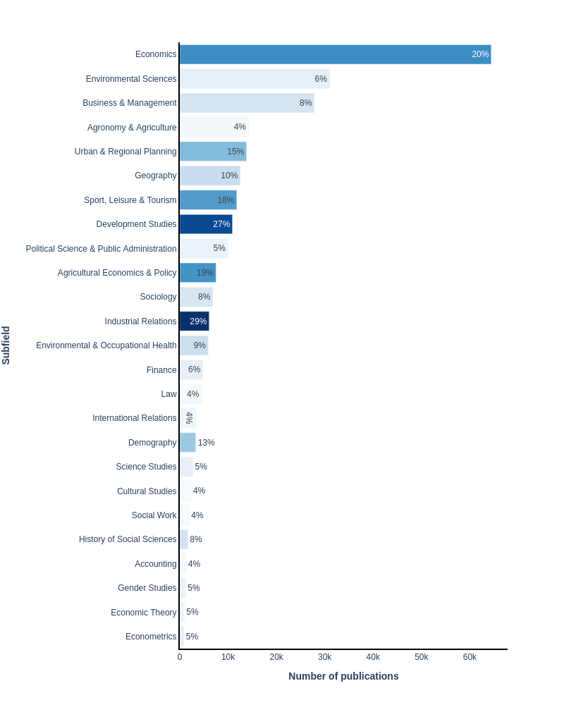

Figure 1. Top 25 subfields with the largest percentage of Scopus publication included in the publication set.

## Journals

In this section, we show how the publication set, captured by the query above, relates to scholarly journals. Journals are sorted in terms of their relevance using term frequency-inverse document frequency (TF-IDF). The horizontal bars are proportional to the number of publications contributed by the journal to the current publication set. The number alongside the horizontal bar is the proportion of the journal contributing to this publication set.

The articles on this topic are published most frequently in the following journals: *Sustainability (Switzerland)* (8,773 publications), *Journal of Cleaner Production* (5,076), and *IOP Conference Series: Earth and Environmental Science* (4,311).

Note, larger journals may not appear in the table below, as their SDG contribution may be relatively small compared to the size of the journal.

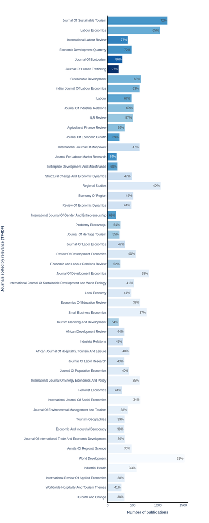

Figure 2. Top 50 journals, in terms of relevance (TF-IDF), for this publication set.

## Keywords

Elsevier’s [Scopus](https://www.scopus.com/search/form.uri?display=basic#basic) database of scientific literature, was used for the table below. The document types included in the data sets are journal articles, reviews, short surveys and conference papers, covering the period 1996–2022. We refer to these documents collectively as “publications” or “papers”.

In order to help better illustrate the content of this set of publications, indicators associated with the keywords most specific to this set (according to a TF-IDF score) are presented below.

|  | Term | # of papers with this term in the publication set | # of papers with this term in all of Scopus | Relevance (TF-IDF) | Percentage of Scopus |
| --- | --- | --- | --- | --- | --- |
| 1 | environmental kuznets curve (ekc) | 1329 | 1488 | 18.6607 | 89 |
| 2 | the environmental kuznets curve | 1550 | 1765 | 18.6523 | 88 |
| 3 | environmental kuznets curve | 2638 | 3018 | 18.6503 | 87 |
| 4 | environmental kuznets | 2679 | 3074 | 18.6432 | 87 |
| 5 | malmquist productivity | 1058 | 1187 | 18.6075 | 89 |
| 6 | job insecurity | 2196 | 2592 | 18.6012 | 85 |
| 7 | eco-efficiency | 2624 | 3100 | 18.5891 | 85 |
| 8 | malmquist productivity index | 951 | 1060 | 18.5889 | 90 |
| 9 | total factor productivity (tfp) | 1927 | 2322 | 18.5628 | 83 |
| 10 | nature-based tourism | 920 | 1042 | 18.5511 | 88 |

[output cut: 990 more lines]